# Import Education & Income data to redcap

Robin Sifre

2021-07-13

```r
# Loads data
source('01_setup_import.R')
```

# Education

## Current data dictionary

`p1_education_self` `p1_education_partner` `p2_education_self` `p2_education_partner`

1, Some schooling |  
2, High school diploma |  
3, Some college/Associate’s degree |  
4, College/Bachelor’s degree |  
5, Advanced degree (MA, MD, PhD, etc.) |  
6, Other |  
7, Other + some other schooling also listed

## Is data in new redcap?

yes

```r
redcap <- read.csv(file.path('redcap-data', 'new_redcap', 'GenderProjectReorg2_DATA.csv'))
redcap %>% pull(p1_education_self) %>% unique() %>% as.numeric()  %>% sort()
```

```
## [1] 2 3 4 5 6 7
```

```r
redcap %>% pull(p2_education_self) %>% unique() %>% as.numeric()  %>% sort()
```

```
## [1] 1 2 3 4 5 6 7
```

```r
redcap %>% pull(p1_education_partner) %>% unique() %>% as.numeric()  %>% sort()
```

```
## [1] 1 2 3 4 5 6 7
```

```r
redcap %>% pull(p2_education_partner) %>% unique() %>% as.numeric()  %>% sort()
```

```
## [1] 1 2 3 4 5 6 7
```

## 2015

1, Some high school (not completed)  
2, High school (2)  
3, College (2 yr)  
4, College (4 yr)  
5, Master’s  
6. Doctorate  
7. N/A

To do:  
- recode 6–>5  
- recode 7–>BLANK

```r
s15<- rbind(s15_gnc %>%
  select(subjectid, child_id,
         education_self = Education,
         education_partner = OtherPEdu),
s15_control %>%
  select(subjectid, child_id,
         education_self = Education,
         education_partner = OtherPEdu))
```

```r
# Check values
s15 %>% pull(education_self) %>% unique()
```

```
## [1]  6  5  4  3 NA  2  1
```

```r
s15 %>% pull(education_partner) %>% unique()
```

```
## [1]  5  6  2  4  1  3 NA  7
```

```r
# Recode
s15 = s15 %>%
  mutate(education_self = as.character(education_self),
         education_partner = as.character(education_partner),
         education_self = recode(education_self, '6' = '5'),
         education_partner = recode(education_partner, '6'='5', '7'=''))
```

```r
# Separate based on parent
s15=s15 %>%
    mutate(parent = ifelse(substr(subjectid, 1,1)==8, 'p1','p2')) %>%
    pivot_wider(id_cols = child_id,
                names_from = parent,
                names_glue = "{parent}_{.value}",
                values_from = c(education_self, education_partner)) %>%
  rename(subjectid = child_id) %>%
  # Add identifier
  mutate(subjectid_visitnum = paste(subjectid, 's15', sep = '_')) %>%
  relocate(subjectid_visitnum)
```

## 2017

1, Some schooling (1)  
2, High school (2)  
3, College (2 yr)  
4, College (4 yr)  
5, Advanced Degree  
6. Other

```r
s17 <- rbind(s17_control %>%
  select(subjectid, child_id,
         education_self = Q116,
         education_self_text = Q116_6_TEXT,
         education_partner = Q125,
         education_partner_text = Q125_6_TEXT),
s17_gnc%>%
  select(subjectid, child_id,
         education_self = Q216,
         education_self_text = Q216_6_TEXT,
         education_partner = Q225,
         education_partner_text = Q225_6_TEXT),
s17_sib %>%
  select(subjectid, child_id,
         education_self = Q119,
         education_self_text = Q119_6_TEXT,
         education_partner = Q128,
         education_partner_text = Q128_6_TEXT))
```

```r
# Check values
s17 %>% pull(education_self) %>% unique()
```

```
## [1]  4  5  3 NA  6  1  2
```

```r
s17 %>% pull(education_partner) %>% unique()
```

```
## [1] NA  3  4  5  2  1  6
```

```r
# Review 'other' cases
s17 %>%
  filter(education_self==6) %>%
  select(subjectid, child_id, education_self_text)
```

```
##   subjectid child_id
## 1      9573      573
## 2     85086     5086
## 3     84027     4027
## 4      8497      497
## 5     84023     4023
##                                                                                                      education_self_text
## 1                                                                                            Completing my MBA in Spring
## 2
## 3 Associates Degree in Science Currently in Sr semester of Nursing School. Graduate in May with a second science degree.
## 4                                                                                                                    DVM
## 5                                                                                           currently in Graduate School
```

```r
# Review 'other' cases
s17 %>%
  filter(education_partner==6) %>%
  select(subjectid, child_id, education_partner_text)
```

```
##   subjectid child_id
## 1     85012     5012
## 2      8565      565
## 3      8497      497
## 4     84091     4091
## 5     83091     3091
##                                               education_partner_text
## 1        some college but no high school diploma.  Classified genius
## 2 College degree in Engineering and Professional Engineering License
## 3                                                               PsyD
## 4                                 High School diploma & trade school
## 5                                  High School diploma, trade school
```

```r
# Manual updates based on text entries
s17[s17$subjectid==9573, 'education_self'] = 4
s17[s17$subjectid==84023, 'education_self'] = 4
s17[s17$subjectid==85012, 'education_partner'] = 3 # Some college
s17[s17$subjectid==8565, 'education_partner'] = 4
s17[s17$subjectid==84091, 'education_partner'] = 2
s17[s17$subjectid==83091, 'education_partner'] = 2
```

```r
s17<-s17 %>%
  select(-c(education_self_text, education_partner_text)) %>%
  mutate(education_self = as.character(education_self),
         education_partner = as.character(education_partner))
```

```r
# Separate based on parent
s17=s17 %>%
    mutate(parent = ifelse(substr(subjectid, 1,1)==8, 'p1','p2')) %>%
    pivot_wider(id_cols = child_id,
                names_from = parent,
                names_glue = "{parent}_{.value}",
                values_from = c(education_self, education_partner)) %>%
  rename(subjectid = child_id) %>%
  # Add identifier
  mutate(subjectid_visitnum = paste(subjectid, 's17', sep = '_')) %>%
  relocate(subjectid_visitnum)
```

## 2018

Not asked

## 2019

1, Some schooling (1)  
2, High school (2)  
3, College (2 yr)  
4, College (4 yr)  
5, Advanced Degree 6. Other  
7. NA (for partner)

To do:  
- recode 7–>BLANK

```r
s19<-rbind(s19_parent_control %>%
  select(subjectid, child_id,
         education_self = Q125,
         education_self_text = Q125_6_TEXT,
         education_partner = Q126,
         education_partner_text = Q126_6_TEXT),
s19_parent_gnc %>%
select(subjectid, child_id,
         education_self = p1_education_self,
         education_self_text = p1_education_self_6_TEXT,
         education_partner = p1_education_part,
         education_partner_text = p1_education_part_6_TEXT) )
```

```r
# Check values
s19 %>% pull(education_self) %>% unique()
```

```
## [1]  5  4 NA  3  6  2
```

```r
s19 %>% pull(education_partner) %>% unique()
```

```
## [1]  4  7  5  2  3 NA  6  1
```

```r
# Recode 7 to blank
s19 = s19 %>%
  mutate(education_self = as.character(education_self),
         education_partner = as.character(education_partner),
         education_partner = recode(education_partner, '7'=''))
```

```r
# Review 'other' cases
s19 %>%
  filter(education_self==6) %>%
  select(subjectid, child_id, education_self_text)
```

```
##   subjectid child_id                                      education_self_text
## 1     85099     5099 Completed part (1/3) of an MA degree, but did not finish
## 2    850012    50012                                some advanced degree- law
## 3    860066    60066               high school with advanced medical training
## 4    860142    60142                       AA and trade school certification
## 5    860149    60149                                                       MD
## 6    860259    60259                                  Currently in Highschool
```

```r
# Review 'other' cases
s19 %>%
  filter(education_partner==6) %>%
  select(subjectid, child_id, education_partner_text)
```

```
##   subjectid child_id                     education_partner_text
## 1      8565      565 Bachelor's plus PE (Professional Engineer)
## 2    860142    60142         AA and trade school certification
## 3    860118    60118                     took some grad classes
```

```r
s19[s19$subjectid==85099, 'education_self'] = '4'
s19[s19$subjectid==850012, 'education_self'] = '4'
s19[s19$subjectid==860066, 'education_self'] = '2'
s19[s19$subjectid==860149, 'education_self'] = '5'
s19[s19$subjectid==860259, 'education_self'] = '1'
s19[s19$subjectid==860066, 'education_self'] = '1'

s19[s19$subjectid==8565, 'education_partner'] = '4'
s19[s19$subjectid==860142, 'education_partner'] = '1'
```

```r
s19 = s19 %>%
  select(-c(education_self_text, education_partner_text))
```

```r
# Separate based on parent
s19=s19 %>%
    mutate(parent = ifelse(substr(subjectid, 1,1)==8, 'p1','p2')) %>%
    pivot_wider(id_cols = child_id,
                names_from = parent,
                names_glue = "{parent}_{.value}",
                values_from = c(education_self, education_partner)) %>%
  rename(subjectid = child_id) %>%
  # Add identifier
  mutate(subjectid_visitnum = paste(subjectid, 's19', sep = '_')) %>%
  relocate(subjectid_visitnum)
```

## 2020

Did not ask

## Finalize education

```r
edu<-rbind(s15, s17, s19)

# Remove rows with no data
edu = edu %>%
  filter(if_any(contains('edu'), ~!is.na(.)))
```

## Convert to text and replace NA with blanks

```r
edu = edu %>%
  # Apply the to_text function
  mutate_at(vars(matches('edu')), to_text)
```

## Check final values

```r
edu %>% pull(p1_education_self) %>% unique() %>% as.numeric() %>% sort()
```

```
## [1] 1 2 3 4 5 6
```

```r
edu %>% pull(p1_education_partner) %>% unique() %>% as.numeric() %>% sort()
```

```
## [1] 1 2 3 4 5 6
```

```r
edu %>% pull(p2_education_self) %>% unique() %>% as.numeric() %>% sort()
```

```
## [1] 1 2 3 4 5
```

```r
edu %>% pull(p2_education_partner) %>% unique() %>% as.numeric() %>% sort()
```

```
## [1] 2 3 4 5
```

## Save

```r
write.csv(edu, 'data_to_import/edu.csv', row.names = FALSE)
```

# Income

## Current Data Dictionary:

1, less than $25,000/yr |  
2, $25,001-$50,000/yr |  
3, $50,001-$75,000/yr |  
4, $75,001-$125,000/yr |  
5, greater than $125,000/yr |  
6, $50,001-$75,000/yr & $75,001-$125,000/yr |  
7, $25,001-$50,000/yr & $50,001-$75,000/yr |  
8, less than $25,000/yr & $25,001-$50,000/yr

## Is data in new redcap?

```r
redcap %>% pull(p1_income) %>% unique() %>% as.numeric() %>% sort()
```

```
## [1] 1 2 3 4 5 6
```

```r
redcap %>% pull(p2_income) %>% unique() %>% as.numeric() %>% sort()
```

```
## [1] 1 2 3 4 5
```

## 2015

1, less than $25,000/yr | 2, $25,001-$50,000/yr | 3, $50,001-$75,000/yr | 4, $75,001-$125,000/yr | 5, greater than $125,000/yr |

```r
s15<-rbind(s15_control %>%
  select(subjectid, child_id,
         income = Income),
s15_gnc %>%
  select(subjectid, child_id,
         income = Income))
```

```r
# Check values
s15 %>% pull(income) %>% unique()
```

```
## [1]  4  5  3 NA  2  1
```

```r
s15 %>% pull(income) %>% unique()
```

```
## [1]  4  5  3 NA  2  1
```

```r
# Separate based on parent
s15=s15 %>%
    mutate(parent = ifelse(substr(subjectid, 1,1)==8, 'p1','p2')) %>%
    pivot_wider(id_cols = child_id,
                names_from = parent,
                names_glue = "{parent}_{.value}",
                values_from = income) %>%
  rename(subjectid = child_id) %>%
  # Add identifier
  mutate(subjectid_visitnum = paste(subjectid, 's15', sep = '_')) %>%
  relocate(subjectid_visitnum)
```

## 2017

- “What is your estimated annual household income”
- Item that I did *not* import because this item does not get asked anywhere else, and I thought it was confusing as this should be the same answer as the first income question: “What is your child’s other parent/guardian’s estimated annual household income”

1, less than $25,000/yr |  
2, $25,001-$50,000/yr |  
3, $50,001-$75,000/yr |  
4, $75,001-$125,000/yr |  
5, greater than $125,000/yr |

```r
s17<-rbind(s17_control %>%
  select(child_id, subjectid,
         income = Q114, income_partner = Q123),
s17_gnc %>%
  select(child_id, subjectid,
         income = Q214, income_partner = Q223),
s17_sib %>%
  select(child_id, subjectid,
         income = Q117, income_partner=Q126))
```

```r
# Check values
s17 %>% pull(income) %>% unique() %>% as.numeric() %>% sort()
```

```
## [1] 1 2 3 4 5
```

```r
s17 %>% pull(income_partner) %>% unique() %>% as.numeric() %>% sort()
```

```
## [1] 1 2 3 4 5
```

```r
# Separate based on parent
s17=s17 %>%
    mutate(parent = ifelse(substr(subjectid, 1,1)==8, 'p1','p2')) %>%
    pivot_wider(id_cols = child_id,
                names_from = parent,
                names_glue = "{parent}_{.value}",
                values_from = c(income, income_partner)) %>%
  rename(subjectid = child_id) %>%
  # Add identifier
  mutate(subjectid_visitnum = paste(subjectid, 's17', sep = '_')) %>%
  relocate(subjectid_visitnum)
```

## 2018

Did not ask

## 2019

```r
s19<-rbind(s19_parent_control %>%
  select(child_id, subjectid,
         income = Q121),
s19_parent_gnc %>%
  select(child_id, subjectid,
         income= s1_p1_household_inco))
```

```r
# Check values
s19 %>% pull(income) %>% unique()
```

```
## [1]  4  5  2  3 NA  1
```

```r
s19 %>% pull(income) %>% unique()
```

```
## [1]  4  5  2  3 NA  1
```

```r
# Separate based on parent
s19=s19 %>%
    mutate(parent = ifelse(substr(subjectid, 1,1)==8, 'p1','p2')) %>%
    pivot_wider(id_cols = child_id,
                names_from = parent,
                names_glue = "{parent}_{.value}",
                values_from = income) %>%
  rename(subjectid = child_id) %>%
  # Add identifier
  mutate(subjectid_visitnum = paste(subjectid, 's19', sep = '_')) %>%
  relocate(subjectid_visitnum)
```

## 2020

Did not ask

## Finalize Income

```r
income<-bind_rows(s15, s17, s19)

# Remove rows with no data
income = income %>%
  filter(if_any(contains('income'), ~!is.na(.)))
```

## Convert to text and replace NA with blanks

```r
income = income %>%
  # Apply the to_text function
  mutate_at(vars(matches('income')), to_text) %>%
  select(-c(subjectid, p1_income_partner, p2_income_partner))
```

## Check final values

```r
income %>% pull(p1_income) %>% unique() %>% as.numeric() %>% sort()
```

```
## [1] 1 2 3 4 5
```

```r
income %>% pull(p2_income) %>% unique() %>% as.numeric() %>% sort()
```

```
## [1] 1 2 3 4 5
```

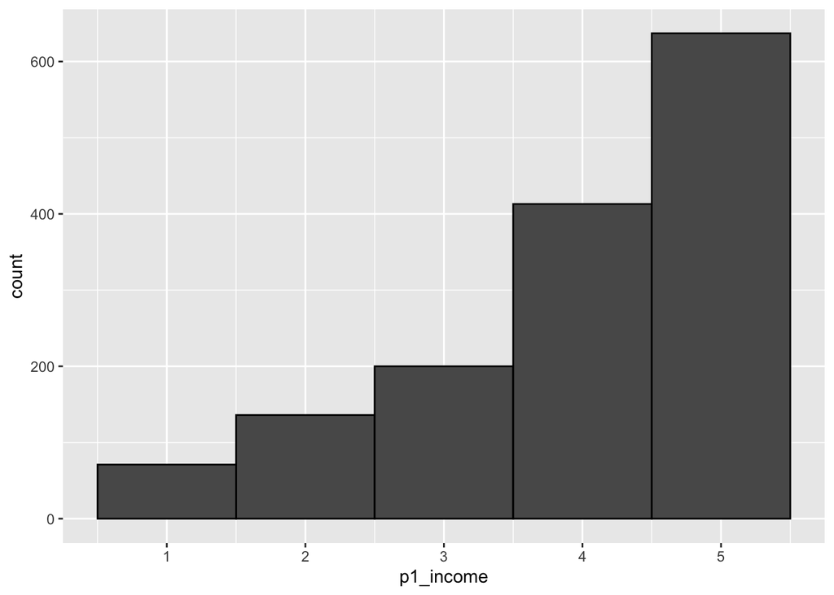

```r
income %>%
  mutate(p1_income = as.numeric(p1_income)) %>%
  filter(!is.na(p1_income)) %>%
ggplot(data = ., aes(x = p1_income)) +
  geom_histogram(binwidth =1, color='black')
```

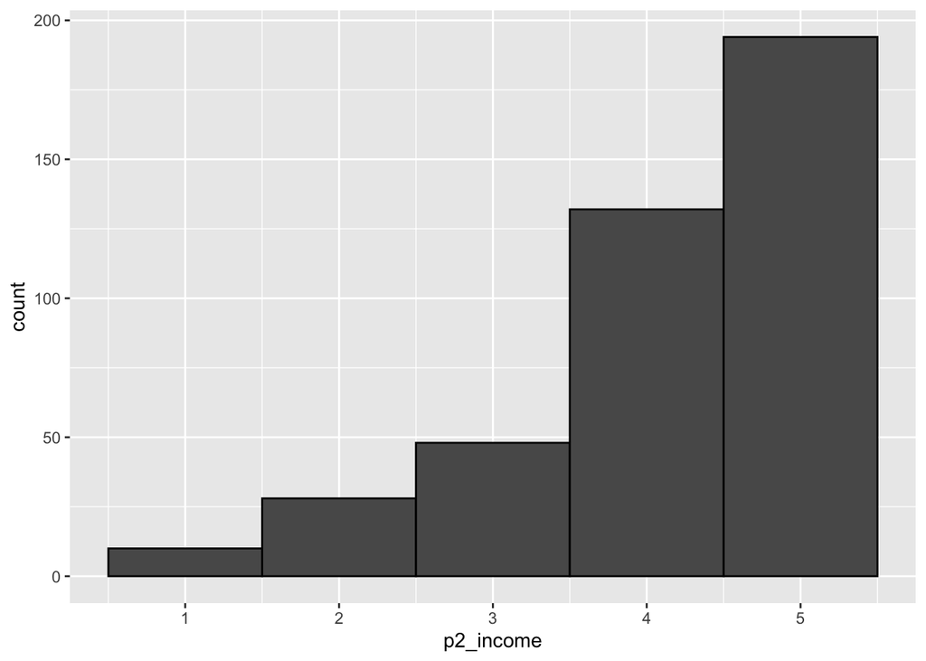

```r
income %>%
  mutate(p2_income = as.numeric(p2_income)) %>%
  filter(!is.na(p2_income)) %>%
ggplot(data = ., aes(x = p2_income)) +
  geom_histogram(binwidth =1, color='black')
```

## Save

```r
write.csv(income, 'data_to_import/income.csv', row.names = FALSE)
```